# Analysis of Weight Lifting Impact Leveraging Multiple Machine Learning Methods

Chris Horvath

January 24, 2016

`https://github.com/chrishorvath/Practical_Machine_Learing`

# Practical Machine Learning - Course Project

## Synopsis

Using devices such as Jawbone Up, Nike FuelBand, and Fitbit it is now possible to collect a large amount of data about personal activity. The goal of this project is to predict the manner in which they did the exercise using data from the following study:

Velloso, E.; Bulling, A.; Gellersen, H.; Ugulino, W.; Fuks, H. Qualitative Activity Recognition of Weight Lifting Exercises. Proceedings of 4th International Conference in Cooperation with SIGCHI (Augmented Human ’13) . Stuttgart, Germany: ACM SIGCHI, 2013.

In the study six participants participated in a dumbbell lifting exercise five different ways (class A-E). Class A being the correct way while the other 4 classes correspond to common mistakes.

## Question

Can the activity class be predicted?

### Setup environment

```r
library(RCurl)
library(AppliedPredictiveModeling)
library(caret)
library(rattle)
```

```r
library(rpart.plot)
library(randomForest)
```

## Input Data

Ultimately, the prediction model is to be run on the test data to predict the outcome of 20 different test cases.

The first step is to import the data and to verify that the training data and the test data are identical.

```r
train_url <- "https://d396qusza40orc.cloudfront.net/predmachlearn/pml-training.csv"
train_file <- "pml-training.csv"
if (!file.exists(train_file)){
  download.file(train_url, train_file, method="libcurl")
}
test_url <- "https://d396qusza40orc.cloudfront.net/predmachlearn/pml-testing.csv"
test_file <- "pml-testing.csv"
if (!file.exists(test_file)){
  download.file(test_url, test_file, method="libcurl")
}

# Load data
train_df <- read.csv(train_file, na.strings=c("NA",""), header=TRUE)
test_df <- read.csv(test_file, na.strings=c("NA",""), header=TRUE)
```

## Features

Remove NA data and remove columns not needed in analysis (more than 95% NA)

```r
nas <- sapply(train_df, function(x) mean(is.na(x))) > 0.95
train_df <- train_df[, !nas]
test_df <- test_df[, !nas]


# Remove columns not used in analysis
train_df <- train_df[,8:length(colnames(train_df))]
test_df <- test_df[,8:length(colnames(test_df))]
```

## Alogrithum

Two different algorithms: classification trees (method = rpart) and random forests (method = rf).

## Parameters

Divide the training set into two roughly equal sets for cross-validation.

```r
set.seed(12345)
idx_train <- createDataPartition(train_df$classe, p=0.5, list=FALSE)
train_df2 <- train_df[idx_train,]
crossvalidation_df <- train_df[-idx_train,]
```

## Evaluation

### Classification Tree

Model with training data

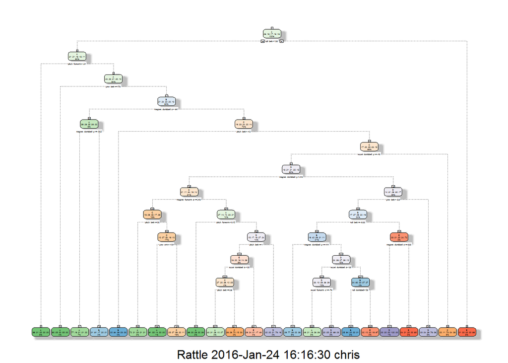

```r
set.seed(12345)
modFitA <- rpart(classe ~ ., data=train_df2, method="class")

fancyRpartPlot(modFitA)
```

Run against cross-validation data

```r
predictions <- predict(modFitA, crossvalidation_df, type = "class")

confusionMatrix(predictions, crossvalidation_df$classe)
```

```
## Confusion Matrix and Statistics
##
##           Reference
## Prediction    A    B    C    D    E
##          A 2445  357  166  106  131
##          B   51 1206  102   66   63
##          C   97  182 1393  360  216
##          D  132   40   45  993  111
##          E   65  113    5   83 1282
##
## Overall Statistics
##
##                Accuracy : 0.7461
##                  95% CI : (0.7373, 0.7547)
##     No Information Rate : 0.2844
##     P-Value [Acc > NIR] : < 2.2e-16
##
##                   Kappa : 0.6772
##  Mcnemar's Test P-Value : < 2.2e-16
##
## Statistics by Class:
##
##                      Class: A Class: B Class: C Class: D Class: E
## Sensitivity            0.8763   0.6354   0.8141   0.6175   0.7110
## Specificity            0.8917   0.9644   0.8944   0.9600   0.9668
## Pos Pred Value         0.7629   0.8105   0.6197   0.7517   0.8282
## Neg Pred Value         0.9478   0.9168   0.9579   0.9276   0.9369
## Prevalence             0.2844   0.1935   0.1744   0.1639   0.1838
## Detection Rate         0.2492   0.1229   0.1420   0.1012   0.1307
## Detection Prevalence   0.3267   0.1517   0.2292   0.1347   0.1578
## Balanced Accuracy      0.8840   0.7999   0.8543   0.7888   0.8389
```

### Random Forest

Model with training data

```r
set.seed(12345)
modFit <- train(train_df2$classe ~ ., method="rf", trControl=trainControl(method = "cv", number = 2), data=train_df2)
```

Run against cross-validation data

```r
predictions <- predict(modFit, newdata=crossvalidation_df)
confusionMatrix(predictions, crossvalidation_df$classe)
```

```
## Confusion Matrix and Statistics
##
##           Reference
## Prediction    A    B    C    D    E
##          A 2782   19    0    0    2
##          B    7 1878    6    0    0
##          C    0    1 1691   27    8
##          D    0    0   14 1578   12
##          E    1    0    0    3 1781
##
## Overall Statistics
##
##                Accuracy : 0.9898
##                  95% CI : (0.9876, 0.9917)
##     No Information Rate : 0.2844
##     P-Value [Acc > NIR] : < 2.2e-16
##
##                   Kappa : 0.9871
##  Mcnemar's Test P-Value : NA
##
## Statistics by Class:
##
##                      Class: A Class: B Class: C Class: D Class: E
## Sensitivity            0.9971   0.9895   0.9883   0.9813   0.9878
## Specificity            0.9970   0.9984   0.9956   0.9968   0.9995
## Pos Pred Value         0.9925   0.9931   0.9792   0.9838   0.9978
## Neg Pred Value         0.9989   0.9975   0.9975   0.9963   0.9973
## Prevalence             0.2844   0.1935   0.1744   0.1639   0.1838
## Detection Rate         0.2836   0.1914   0.1724   0.1609   0.1815
## Detection Prevalence   0.2857   0.1928   0.1760   0.1635   0.1820
## Balanced Accuracy      0.9971   0.9939   0.9919   0.9891   0.9936
```

# Conclusion

Using the classification tree model using a simple cross-validation method the accuracy was a bit low at 0.7461.

Using the same binary cross-validation with random forest model the accuracy was greatly increased to 0.9898. The model attributes are as follows

```r
modFit$finalModel
```

```
##
## Call:
##  randomForest(x = x, y = y, mtry = param$mtry)
##                Type of random forest: classification
##                      Number of trees: 500
## No. of variables tried at each split: 27
##
##         OOB estimate of  error rate: 0.99%
## Confusion matrix:
##      A    B    C    D    E class.error
## A 2785    2    3    0    0 0.001792115
## B   15 1873   11    0    0 0.013691417
## C    0   17 1687    7    0 0.014026885
## D    0    1   24 1582    1 0.016169154
## E    0    1    5   10 1788 0.008869180
```

I received following predicted against the 20 item test set:

```r
print(predict(modFit, test_df))
```

```
##  [1] B A B A A E D B A A B C B A E E A B B B
## Levels: A B C D E
```